# danmorper2TrabajoTema3

DanielMorenoPerez

2023-04-10

# Librerías, y definiciones previas

Cargamos librerías

```r
library(KernSmooth)
library(dplyr)
```

Definimos la función de densidad real, rejilla de valores representativos de la v.a. Z y número de muestras y los tamaños de muestra

```r
# Función densidad real
real_dens <- function(x) {
  0.5 * dnorm(x, mean = -1.5) + 0.5 * dnorm(x, mean = 1.5)
}

# Creamos la rejilla de valores representativos de la v.a. Z
M <- 1000
rejilla_min <- -4.5
rejilla_max <- 4.5
n_rejilla <- 512
rejilla <- seq(rejilla_min, rejilla_max, length = n_rejilla)
densidad_real <- real_dens(rejilla)
```

# Métodos y simulación

```r
# Definimos los métodos I y II
h_I = "bcv"

h_II = "SJ"
```

# n = 50

```r
n <- 50
```

## Método 1

Realizamos las simulaciones:

```r
# Realizamos las simulaciones
results_I_50 <- matrix(data = numeric(n_rejilla*M), ncol = n_rejilla, nrow = M)
cont = 0 # para ver si funciona, debe llegar hasta 2000 (ns*M)
for (i in 1:M) {
  # Generamos la muestra X
  elegir_var <- rbinom(n = n, size = 1, prob = 0.5)
  X <- elegir_var*rnorm(n, mean = -1.5) + (1-elegir_var)*rnorm(n, mean = 1.5) # Corrijo toma de muestra

  # Calculamos la densidad estimada con el método I
  estimacion <- density(X, bw = h_I, kernel = "gaussian", from = rejilla_min, to = rejilla_max, n = n_rejilla)

  # Guardamos resultados
  results_I_50[i,] <- estimacion$y

  #cont = cont + 1
  #print(cont)
}
results_I_50[1:10,1:12]
```

```
##              [,1]        [,2]        [,3]        [,4]        [,5]        [,6]
##  [1,] 0.022289093 0.022757682 0.023237658 0.023725954 0.024223924 0.024732748
##  [2,] 0.009444090 0.009774902 0.010109325 0.010459402 0.010813517 0.011179901
##  [3,] 0.021680717 0.022072905 0.022469946 0.022871613 0.023277114 0.023688494
##  [4,] 0.010635723 0.010953813 0.011282376 0.011615772 0.011958035 0.012307103
##  [5,] 0.007769369 0.008081828 0.008402131 0.008732020 0.009073923 0.009421799
##  [6,] 0.005883631 0.006138520 0.006405409 0.006680244 0.006964403 0.007260226
##  [7,] 0.009388841 0.009729921 0.010084218 0.010447041 0.010820723 0.011206190
##  [8,] 0.014590648 0.015045692 0.015516282 0.015991410 0.016478352 0.016973492
##  [9,] 0.009561622 0.009942509 0.010343434 0.010748106 0.011175271 0.011607531
## [10,] 0.018156134 0.018567270 0.018981950 0.019402258 0.019827857 0.020257297
##              [,7]        [,8]        [,9]       [,10]       [,11]       [,12]
##  [1,] 0.025249382 0.025779568 0.026315541 0.026867932 0.027423926 0.027999368
##  [2,] 0.011554327 0.011937431 0.012332765 0.012732989 0.013149805 0.013570771
##  [3,] 0.024102647 0.024523998 0.024947017 0.025378628 0.025811463 0.026252932
##  [4,] 0.012663345 0.013028434 0.013398929 0.013780375 0.014165382 0.014563504
##  [5,] 0.009786089 0.010154471 0.010539935 0.010931691 0.011336723 0.011752576
##  [6,] 0.007562416 0.007880273 0.008201654 0.008542203 0.008886956 0.009247833
##  [7,] 0.011599954 0.012008965 0.012423507 0.012856958 0.013293584 0.013751751
##  [8,] 0.017476710 0.017991720 0.018511097 0.019045766 0.019584015 0.020135186
##  [9,] 0.012059101 0.012520060 0.012996866 0.013487620 0.013990478 0.014512096
## [10,] 0.020693768 0.021132310 0.021579621 0.022028682 0.022485381 0.022945271
```

### ECM, sesgo y varianza

```r
# Calculo correctamente ECM, sesgo y varianza
sesgo_I_50 <- colMeans(results_I_50) - densidad_real
varianza_I_50 <- apply(results_I_50, 2, var)
ECM_I_50 <- varianza_I_50 + sesgo_I_50^2
ECM_I_50_est <- mean(varianza_I_50 + sesgo_I_50^2)
```

Cada elemento del vector sesgo es el sesgo al estimar un valor de la densidad en la rejilla

## Método 2

```r
# Realizamos las simulaciones
results_II_50 <- matrix(data = numeric(n_rejilla*M), ncol = n_rejilla, nrow = M)
cont = 0 # para ver si funciona, debe llegar hasta 2000 (ns*M)
for (i in 1:M) {
  # Generamos la muestra X
  elegir_var <- rbinom(n = n, size = 1, prob = 0.5)
  X <- elegir_var*rnorm(n, mean = -1.5) + (1-elegir_var)*rnorm(n, mean = 1.5)

  # Calculamos la densidad estimada con el método I
  estimacion <- density(X, bw = h_II, kernel = "gaussian", from = rejilla_min, to = rejilla_max, n = n_rejilla)

  # Guardamos resultados
  results_II_50[i,] <- estimacion$y

  #cont = cont + 1
  #print(cont)
  }
results_II_50[1:10,1:12]
```

```
##               [,1]         [,2]         [,3]         [,4]         [,5]
##  [1,] 0.0009672414 0.0010414080 0.0011198524 0.0012055822 0.0012950007
##  [2,] 0.0106489394 0.0109490165 0.0112568466 0.0115728388 0.0118936979
##  [3,] 0.0112751911 0.0116693855 0.0120770869 0.0124906560 0.0129227023
##  [4,] 0.0008837886 0.0009671155 0.0010555845 0.0011527497 0.0012577129
##  [5,] 0.0097579653 0.0100397686 0.0103300622 0.0106236423 0.0109228285
##  [6,] 0.0001266249 0.0001403717 0.0001558948 0.0001729604 0.0001912217
##  [7,] 0.0059735435 0.0063366688 0.0067118517 0.0071055645 0.0075225701
##  [8,] 0.0028745344 0.0030326185 0.0032005981 0.0033726069 0.0035570012
##  [9,] 0.0164264143 0.0168567853 0.0172932808 0.0177375995 0.0181856628
## [10,] 0.0049048296 0.0052175434 0.0055513193 0.0058995712 0.0062600058
##               [,6]         [,7]         [,8]         [,9]        [,10]
##  [1,] 0.0013911302 0.0014941059 0.0016012840 0.0017182920 0.0018412558
##  [2,] 0.0122264700 0.0125626995 0.0129114178 0.0132656641 0.0136292732
##  [3,] 0.0133594005 0.0138134670 0.0142756159 0.0147507899 0.0152392132
```

[output cut: 18 more lines]

### ECM, sesgo y varianza

```r
sesgo_II_50 <- colMeans(results_II_50) - densidad_real
varianza_II_50 <- apply(results_II_50, 2, var)
ECM_II_50 <- varianza_II_50 + sesgo_II_50^2
ECM_II_50_est <- mean(ECM_II_50)
```

# n = 100

```r
n <- 100
```

## Metodo 1

Realizamos las simulaciones:

```r
# Realizamos las simulaciones
results_I_100 <- matrix(data = numeric(n_rejilla*M), ncol = n_rejilla, nrow = M)
cont = 0 # para ver si funciona, debe llegar hasta 2000 (ns*M)
for (i in 1:M) {
  # Generamos la muestra X
  elegir_var <- rbinom(n = n, size = 1, prob = 0.5)
  X <- elegir_var*rnorm(n, mean = -1.5) + (1-elegir_var)*rnorm(n, mean = 1.5)

  # Calculamos la densidad estimada con el método I
  estimacion <- density(X, bw = h_I, kernel = "gaussian", from = rejilla_min, to = rejilla_max, n = n_rejilla)

  # Guardamos resultados
  results_I_100[i,] <- estimacion$y

  #cont = cont + 1
  #print(cont)
  }
results_I_100[1:10,1:12]
```

```
##              [,1]        [,2]        [,3]        [,4]        [,5]        [,6]
##  [1,] 0.005236882 0.005473274 0.005724347 0.005979946 0.006247429 0.006523823
##  [2,] 0.010309032 0.010617935 0.010933121 0.011256157 0.011589657 0.011927405
##  [3,] 0.008892433 0.009243146 0.009600141 0.009968678 0.010348755 0.010735569
##  [4,] 0.004447423 0.004684694 0.004928509 0.005186165 0.005452744 0.005726706
##  [5,] 0.010543168 0.010849755 0.011164865 0.011484597 0.011817111 0.012153676
##  [6,] 0.018999804 0.019459356 0.019926063 0.020399247 0.020881871 0.021368723
##  [7,] 0.006965191 0.007221071 0.007486671 0.007755863 0.008034089 0.008318224
##  [8,] 0.008008539 0.008349313 0.008695784 0.009056307 0.009427755 0.009807795
##  [9,] 0.007172024 0.007430830 0.007701268 0.007975617 0.008260475 0.008552264
## [10,] 0.011088744 0.011456347 0.011838892 0.012226722 0.012625541 0.013034106
##              [,7]        [,8]        [,9]       [,10]       [,11]       [,12]
##  [1,] 0.006807867 0.007106128 0.007409405 0.007728624 0.008055243 0.008393084
##  [2,] 0.012280119 0.012637061 0.013006023 0.013383427 0.013768910 0.014167722
##  [3,] 0.011139415 0.011548559 0.011973206 0.012406990 0.012851151 0.013310167
##  [4,] 0.006017202 0.006315221 0.006623653 0.006947266 0.007278843 0.007624202
##  [5,] 0.012501198 0.012856256 0.013218439 0.013592808 0.013971606 0.014364680
##  [6,] 0.021867291 0.022368129 0.022882330 0.023399099 0.023926936 0.024459584
##  [7,] 0.008607853 0.008907168 0.009210207 0.009523050 0.009841564 0.010166197
##  [8,] 0.010205180 0.010608748 0.011029593 0.011460382 0.011902488 0.012361397
##  [9,] 0.008850839 0.009160818 0.009475079 0.009802522 0.010136037 0.010478653
## [10,] 0.013449525 0.013879310 0.014313564 0.014763100 0.015219179 0.015686199
```

### ECM, sesgo y varianza

```r
sesgo_I_100 <- colMeans(results_I_100) - densidad_real
varianza_I_100 <- apply(results_I_100, 2, var)
ECM_I_100 <- varianza_I_100 + sesgo_I_100^2
ECM_I_100_est <- mean(ECM_I_100)
```

## Método 2

```r
# Realizamos las simulaciones ----
results_II_100 <- matrix(data = numeric(n_rejilla*M), ncol = n_rejilla, nrow = M)
cont = 0 # para ver si funciona, debe llegar hasta 2000 (ns*M)
for (i in 1:M) {
  # Generamos la muestra X
  elegir_var <- rbinom(n = n, size = 1, prob = 0.5)
  X <- elegir_var*rnorm(n, mean = -1.5) + (1-elegir_var)*rnorm(n, mean = 1.5)

  # Calculamos la densidad estimada con el método I
  estimacion <- density(X, bw = h_II, kernel = "gaussian", from = rejilla_min, to = rejilla_max, n = n_rejilla)

  # Guardamos resultados
  results_II_100[i,] <- estimacion$y

  #cont = cont + 1
  #print(cont)
  }
results_II_100[1:10,1:12]
```

```
##              [,1]        [,2]        [,3]        [,4]        [,5]        [,6]
##  [1,] 0.002062238 0.002215917 0.002376938 0.002551757 0.002734372 0.002924818
##  [2,] 0.001866586 0.001999809 0.002142718 0.002291607 0.002446520 0.002610559
##  [3,] 0.006151463 0.006443416 0.006751447 0.007066617 0.007395363 0.007736953
##  [4,] 0.011962417 0.012446758 0.012945338 0.013461009 0.013984888 0.014530504
##  [5,] 0.009689210 0.010007623 0.010331976 0.010660175 0.010996219 0.011337045
##  [6,] 0.010772231 0.010994830 0.011222046 0.011453224 0.011689597 0.011934139
##  [7,] 0.012777160 0.013199601 0.013628730 0.014065275 0.014506630 0.014953415
##  [8,] 0.002690366 0.002870463 0.003059925 0.003262616 0.003473286 0.003694536
##  [9,] 0.010126424 0.010505306 0.010900075 0.011302335 0.011714936 0.012141205
## [10,] 0.017785481 0.018217985 0.018653127 0.019091114 0.019530672 0.019972927
##              [,7]        [,8]        [,9]       [,10]       [,11]       [,12]
##  [1,] 0.003130759 0.003345627 0.003569184 0.003808998 0.004059353 0.004319215
##  [2,] 0.002782328 0.002960429 0.003146206 0.003341777 0.003543857 0.003752461
##  [3,] 0.008086057 0.008454375 0.008831645 0.009220768 0.009627388 0.010042396
##  [4,] 0.015086452 0.015655985 0.016244376 0.016841228 0.017459101 0.018088703
##  [5,] 0.011681876 0.012035330 0.012392637 0.012755108 0.013125179 0.013499173
##  [6,] 0.012184683 0.012441459 0.012710658 0.012988415 0.013274716 0.013574860
##  [7,] 0.015407914 0.015866840 0.016330159 0.016801006 0.017275995 0.017754943
##  [8,] 0.003930382 0.004175073 0.004431618 0.004704135 0.004986382 0.005281803
##  [9,] 0.012573523 0.013022906 0.013480081 0.013948392 0.014431006 0.014920015
## [10,] 0.020417329 0.020863163 0.021311844 0.021762210 0.022214012 0.022668915
```

### ECM, sesgo y varianza

```r
sesgo_II_100 <- colMeans(results_II_100) - densidad_real
varianza_II_100 <- apply(results_II_100, 2, var)
ECM_II_100 <- varianza_II_100 + sesgo_II_100^2
ECM_II_100_est <- mean(ECM_II_100)
```

# ¿Diferencias significativa de ECM entre distintos métodos?

## n = 50

Estudio descripitvo

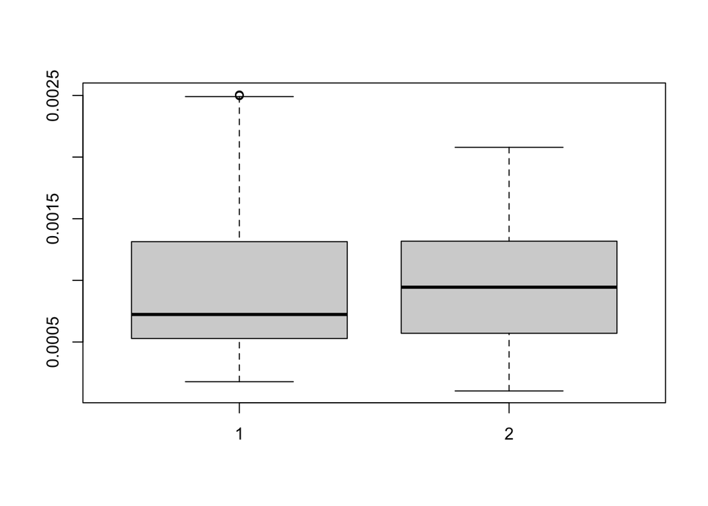

```r
boxplot(ECM_I_50, ECM_II_50)
```

```r
summary(data_frame(ECM_I_50, ECM_II_50))
```

```
##     ECM_I_50           ECM_II_50
##  Min.   :0.0001776   Min.   :0.0001030
##  1st Qu.:0.0005282   1st Qu.:0.0005712
##  Median :0.0007232   Median :0.0009446
##  Mean   :0.0009877   Mean   :0.0009786
##  3rd Qu.:0.0013127   3rd Qu.:0.0013170
##  Max.   :0.0025050   Max.   :0.0020790
```

Boxplots algo disintos, pero nada especialmente relevante.

### Estudio inferencial

```r
shapiro.test(ECM_I_50)
```

```
##
##  Shapiro-Wilk normality test
##
## data:  ECM_I_50
## W = 0.84674, p-value < 2.2e-16
```

```r
shapiro.test(ECM_II_50)
```

```
##
##  Shapiro-Wilk normality test
##
## data:  ECM_II_50
## W = 0.94451, p-value = 6.504e-13
```

Ambos pvalores menores que 0.05, luego rechazo normalidad

Hago el test no paramétrico de wilcoxon.

```r
wilcox.test(ECM_I_50, ECM_II_50)
```

```
##
##  Wilcoxon rank sum test with continuity correction
##
## data:  ECM_I_50 and ECM_II_50
## W = 127295, p-value = 0.4248
## alternative hypothesis: true location shift is not equal to 0
```

## n = 100

### Estudio descripitvo

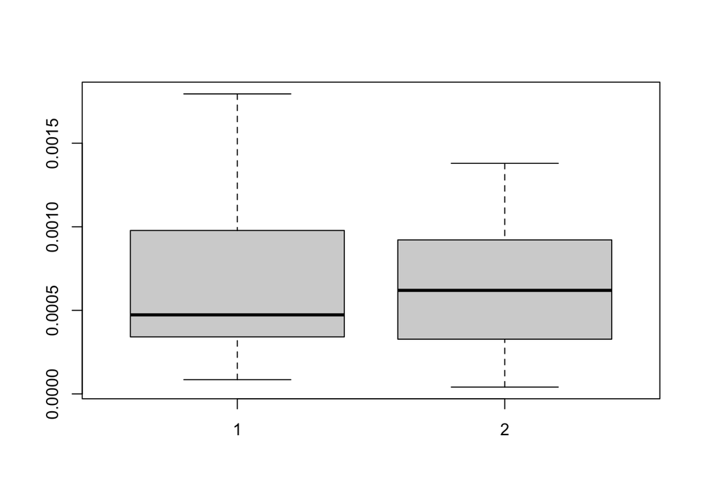

```r
boxplot(ECM_I_100, ECM_II_100)
```

```r
summary(data_frame(ECM_I_100, ECM_II_100))
```

```
##    ECM_I_100           ECM_II_100
##  Min.   :8.518e-05   Min.   :4.083e-05
##  1st Qu.:3.413e-04   1st Qu.:3.277e-04
##  Median :4.729e-04   Median :6.195e-04
##  Mean   :6.715e-04   Mean   :6.267e-04
##  3rd Qu.:9.779e-04   3rd Qu.:9.204e-04
##  Max.   :1.795e-03   Max.   :1.380e-03
```

Se puedo apreciar en en los boxplots que son ligeramente distintos, pero nada concluyente

### Estudio inferencial

```r
shapiro.test(ECM_I_100)
```

```
##
##  Shapiro-Wilk normality test
##
## data:  ECM_I_100
## W = 0.8626, p-value < 2.2e-16
```

```r
shapiro.test(ECM_II_100)
```

```
##
##  Shapiro-Wilk normality test
##
## data:  ECM_II_100
## W = 0.94979, p-value = 3.599e-12
```

Ambos pvalores menores que 0.05, luego rechazo normalidad

Hago el test no paramétrico de wilcoxon.

```r
wilcox.test(ECM_I_100, ECM_II_100)
```

```
##
##  Wilcoxon rank sum test with continuity correction
##
## data:  ECM_I_100 and ECM_II_100
## W = 134200, p-value = 0.5087
## alternative hypothesis: true location shift is not equal to 0
```

# Fijo método 1, ¿diferencias entre distintos n?

## Estudio descriptivo

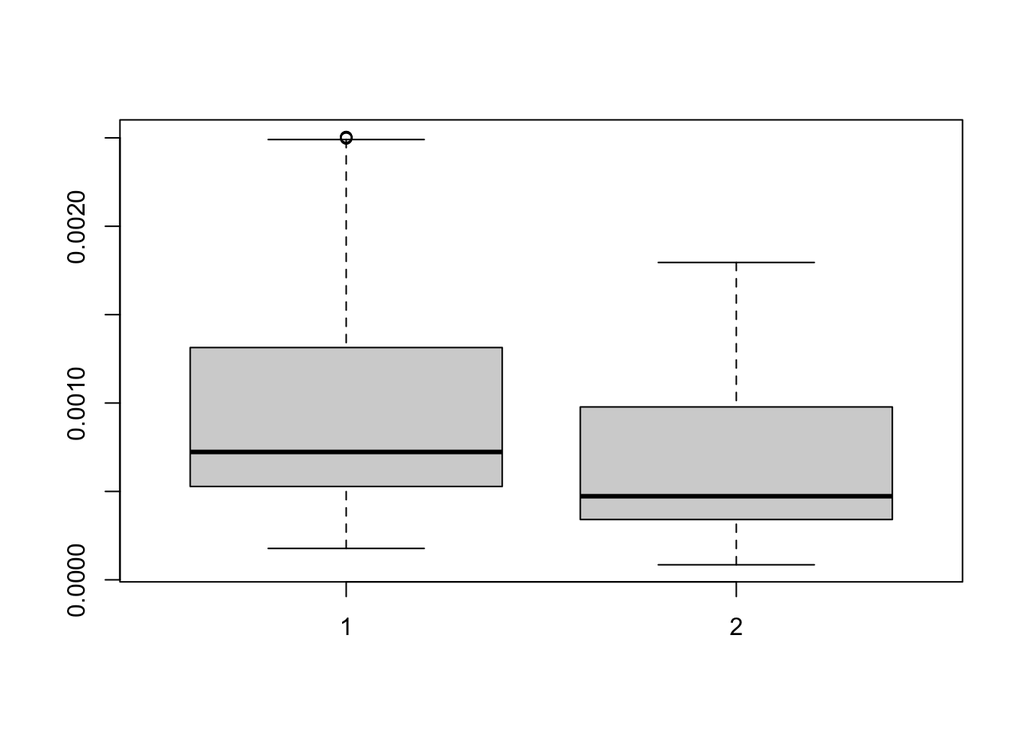

```r
boxplot(ECM_I_50, ECM_I_100)
```

```r
summary(data_frame(ECM_I_50, ECM_I_100))
```

```
##     ECM_I_50           ECM_I_100
##  Min.   :0.0001776   Min.   :8.518e-05
##  1st Qu.:0.0005282   1st Qu.:3.413e-04
##  Median :0.0007232   Median :4.729e-04
##  Mean   :0.0009877   Mean   :6.715e-04
##  3rd Qu.:0.0013127   3rd Qu.:9.779e-04
##  Max.   :0.0025050   Max.   :1.795e-03
```

## Estudio inferencial

```r
shapiro.test(ECM_I_50)
```

```
##
##  Shapiro-Wilk normality test
##
## data:  ECM_I_50
## W = 0.84674, p-value < 2.2e-16
```

```r
shapiro.test(ECM_I_100)
```

```
##
##  Shapiro-Wilk normality test
##
## data:  ECM_I_100
## W = 0.8626, p-value < 2.2e-16
```

Ambos pvalores menores que 0.05, luego rechazo normalidad

Hago el test no paramétrico de wilcoxon.

```r
wilcox.test(ECM_I_50, ECM_I_100)
```

```
##
##  Wilcoxon rank sum test with continuity correction
##
## data:  ECM_I_50 and ECM_I_100
## W = 177477, p-value < 2.2e-16
## alternative hypothesis: true location shift is not equal to 0
```

Existen diferencias en ECM entre los distintos n fijando el método 1.

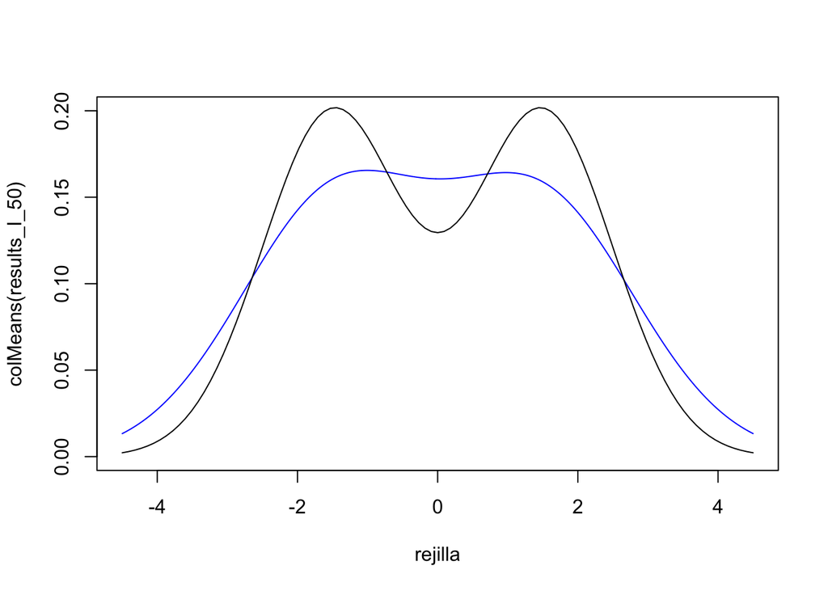

```r
plot(rejilla, colMeans(results_I_50), ylim = c(0, 0.20),  type = "l", col = "blue")
curve(real_dens, from = rejilla_min, to = rejilla_max, add = TRUE)
```

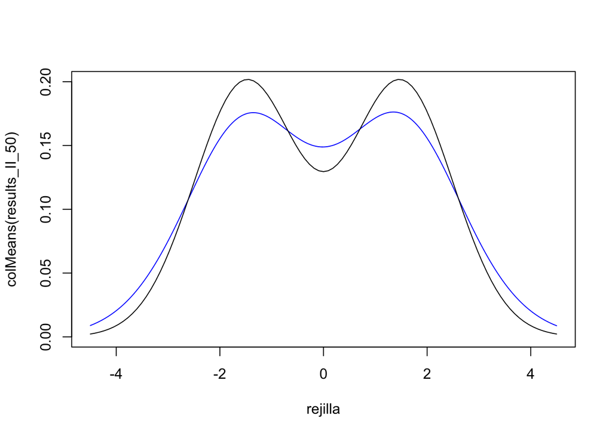

```r
plot(rejilla, colMeans(results_II_50), ylim = c(0, 0.20),  type = "l", col = "blue")
curve(real_dens, from = rejilla_min, to = rejilla_max, add = TRUE)
```

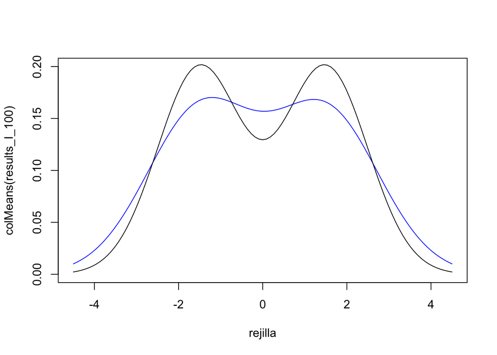

```r
plot(rejilla, colMeans(results_I_100), ylim = c(0, 0.20),  type = "l", col = "blue")
curve(real_dens, from = rejilla_min, to = rejilla_max, add = TRUE)
```

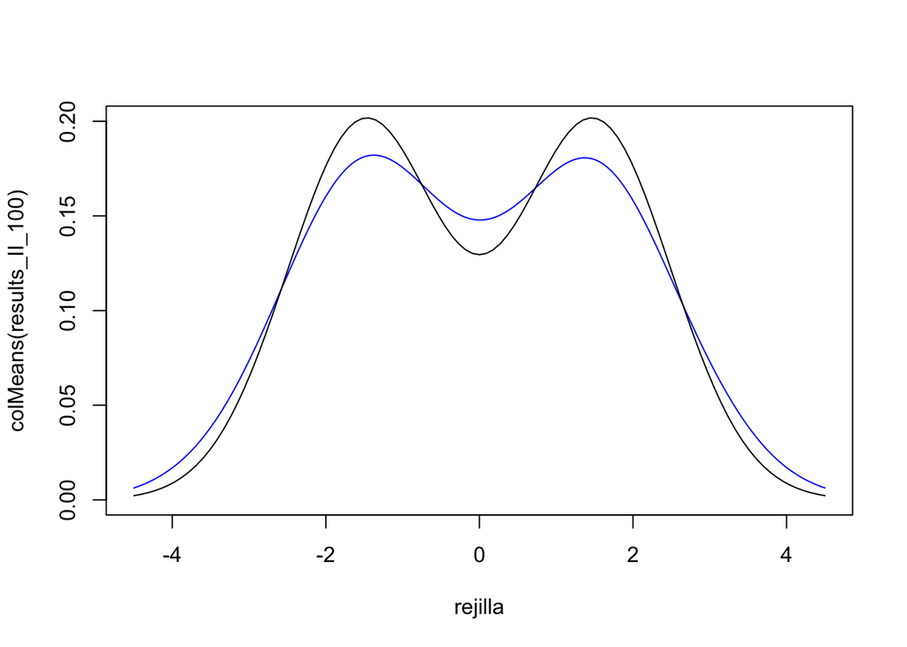

```r
plot(rejilla, colMeans(results_II_100), ylim = c(0, 0.20),  type = "l", col = "blue")
curve(real_dens, from = rejilla_min, to = rejilla_max, add = TRUE)
```